# Clase 5. GLM-Poisson: Ejercicio

Oscar Carmona Castro

2025-03-25

## Ejercicio.

Elaborar una tabla de selección de modelos para identificar el modelo o los modelos más adecuados para explicar la abundancia del mejillón de agua dulce de Nueva Zelanda (Anodonta anatina). Realizar la validación y graficado del modelo (**instructor: David Murillo**).

## 1. Cargar paquetes

```r
library(tidyverse)
library(DHARMa)
library(AICcmodavg)
library(ggeffects)
```

## 2. Cargar base de datos (mejillones)

```r
mejillones = read.table("https://www.dropbox.com/s/q8tpwcfsh232g4s/muss.txt?dl=1", header = T, dec = ".", stringsAsFactors = T)

View(mejillones)
```

**Variables:**

- depth: Profundidad del agua
- subs: substrato, es un factor con tres niveles (gravel, mud, sand)
- unio: abundancia de Unio pictorum + U. tumidus
- duck: abundancia de New Zealand duck mussel o Anodonta anatina
- swan: abundancia de The swan mussel, o Anodonta cygnea

Convertir variable “subs” a factor

```r
mejillones$subs = factor(mejillones$subs)
head(mejillones)
```

```
##   depth subs unio duck swan
## 1  0.08  mud    0    0    0
## 2  0.12  mud    0    0    0
## 3  0.14  mud    0    0    0
## 4  0.17  mud    0    0    0
## 5  0.18  mud    0    0    0
## 6  0.24  mud    0    1    0
```

## 3. Ajuste de modelos

```r
Modelos_duck = list(

"profundidad" = glm(duck ~ depth, family = "poisson", data = mejillones),
"sustrato" = glm(duck ~ subs, family = "poisson", data = mejillones),
"pro_y-sus" = glm(duck ~ depth + subs, family = "poisson", data = mejillones),

"int_pro_sus" = glm(duck ~ depth*subs, family = "poisson", data = mejillones),
"int2_pro_sus" = glm(duck ~ depth:subs, family = "poisson", data = mejillones),
"nulo" = glm(duck ~ 1, family = "poisson", data = mejillones)

)
```

## 4. Selección de modelos

```r
aictab(Modelos_duck)
```

```
##
## Model selection based on AICc:
##
##              K   AICc Delta_AICc AICcWt Cum.Wt      LL
## int_pro_sus  6 306.58       0.00   0.51   0.51 -146.81
## profundidad  2 307.90       1.32   0.26   0.78 -151.89
## int2_pro_sus 4 309.05       2.47   0.15   0.92 -150.30
## pro_y-sus    4 310.89       4.31   0.06   0.98 -151.22
## nulo         1 314.70       8.12   0.01   0.99 -156.33
## sustrato     3 314.98       8.39   0.01   1.00 -154.36
```

Los modelos explican el 100% de la abundancia del mejillón Anodonta anatina (columna AIC cWt). Sin embargo seleccionamos los modelos que explican ≈80% de la distribución del mejillón (Modelo1 = int_pro_sus: 51%; Modelo2 = profundidad: 26%).

## 5. Validación de los modelos

### 5.1 Modelo1 = int_pro_sus

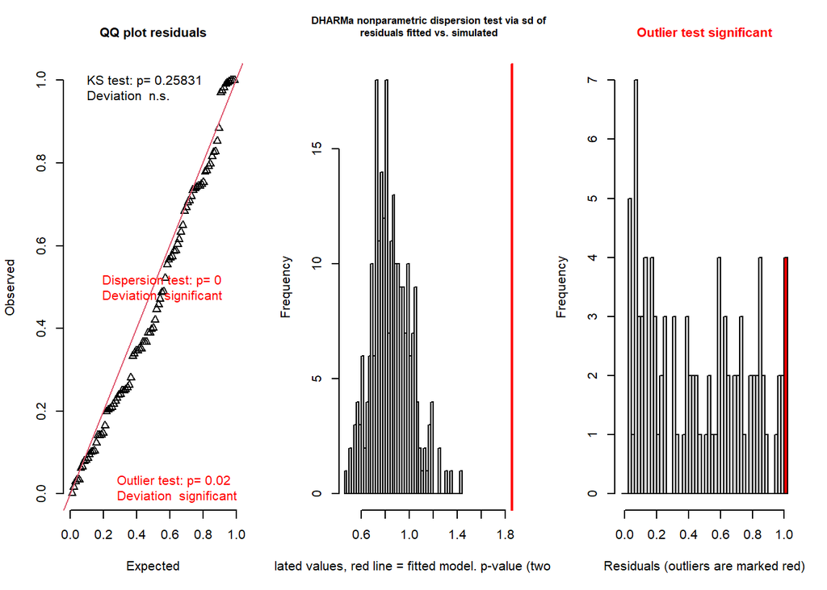

[output not shown]

```r
testResiduals(Modelos_duck$int_pro_sus)
```

Prueba de sobredispersión

```r
testOverdispersion(Modelos_duck$int_pro_sus)
```

```
## testOverdispersion is deprecated, switch your code to using the testDispersion function
```

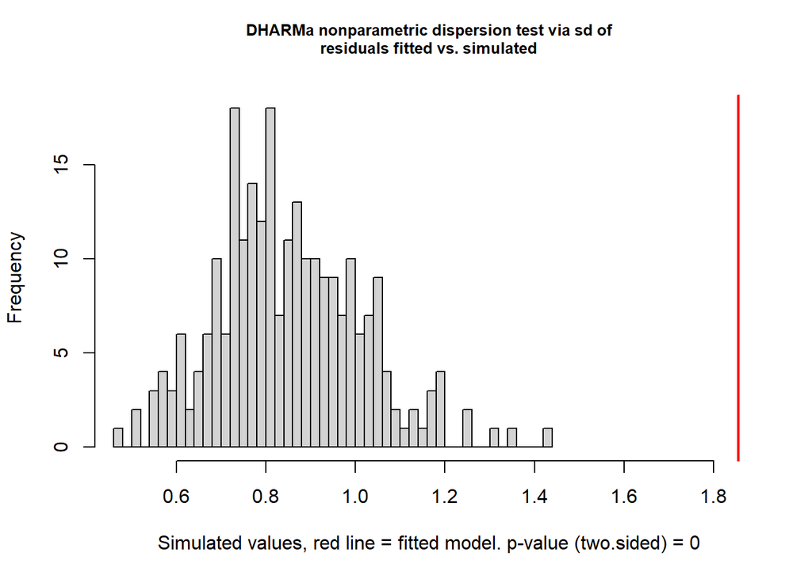

```
##
##  DHARMa nonparametric dispersion test via sd of residuals fitted vs.
##  simulated
##
## data:  simulationOutput
## dispersion = 2.1797, p-value < 2.2e-16
## alternative hypothesis: two.sided
```

### 5.2 Modelo2 = profundidad

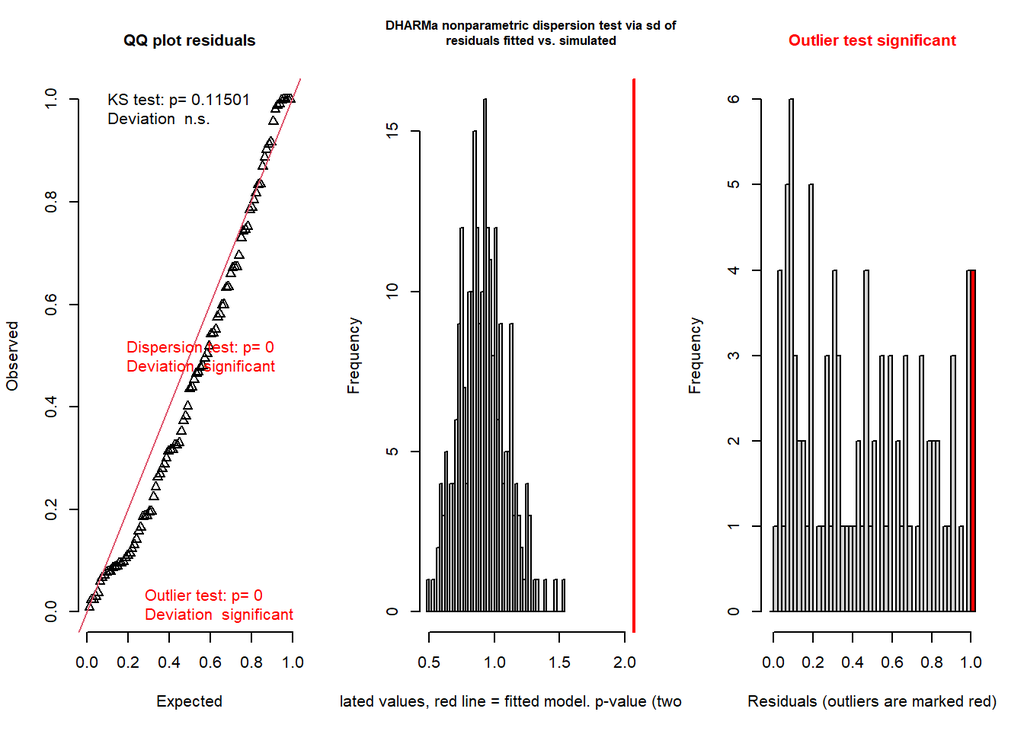

[output not shown]

```r
testResiduals(Modelos_duck$profundidad)
```

Prueba de sobredispersión.

```r
testOverdispersion(Modelos_duck$profundidad)
```

```
## testOverdispersion is deprecated, switch your code to using the testDispersion function
```

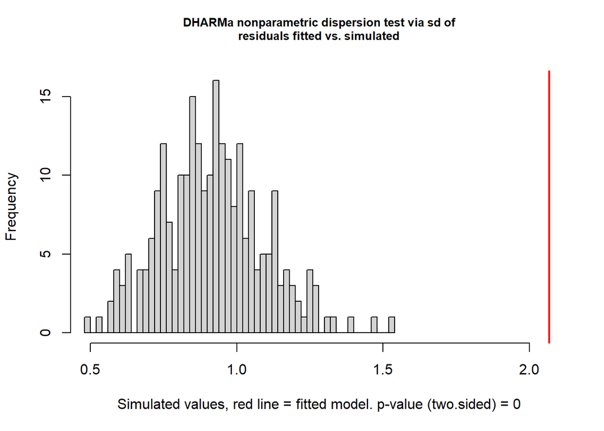

```
##
##  DHARMa nonparametric dispersion test via sd of residuals fitted vs.
##  simulated
##
## data:  simulationOutput
## dispersion = 2.252, p-value < 2.2e-16
## alternative hypothesis: two.sided
```

## 6 Interpretación de los modelos (summary)

### 6.1 Modelo1 = int_pro_sus

```r
summary(Modelos_duck$int_pro_sus)
```

```
##
## Call:
## glm(formula = duck ~ depth * subs, family = "poisson", data = mejillones)
##
## Coefficients:
##                Estimate Std. Error z value Pr(>|z|)
## (Intercept)      1.0670     0.6824   1.564  0.11793
## depth           -1.6782     0.9371  -1.791  0.07332 .
## subsmud         -1.2703     0.7357  -1.727  0.08421 .
## subssand        -2.4048     0.9495  -2.533  0.01131 *
## depth:subsmud    2.0096     0.9492   2.117  0.03424 *
## depth:subssand   2.7091     1.0417   2.601  0.00931 **
## ---
## Signif. codes:  0 '***' 0.001 '**' 0.01 '*' 0.05 '.' 0.1 ' ' 1
##
## (Dispersion parameter for poisson family taken to be 1)
##
##     Null deviance: 182.92  on 94  degrees of freedom
## Residual deviance: 163.89  on 89  degrees of freedom
## AIC: 305.63
##
## Number of Fisher Scoring iterations: 6
```

Intervalos de confianza

```r
confint(Modelos_duck$int_pro_sus)
```

```
##                     2.5 %      97.5 %
## (Intercept)    -0.2856923  2.42666455
## depth          -3.7913020 -0.04966198
## subsmud        -2.7345626  0.17956324
## subssand       -4.3525364 -0.59734465
## depth:subsmud   0.3515768  4.14085573
## depth:subssand  0.8465389  4.99076466
```

```r
coef(Modelos_duck$int_pro_sus)
```

```
##    (Intercept)          depth        subsmud       subssand  depth:subsmud
##       1.067003      -1.678152      -1.270305      -2.404845       2.009644
## depth:subssand
##       2.709065
```

```r
car::vif(Modelos_duck$int_pro_sus)
```

```
## there are higher-order terms (interactions) in this model
## consider setting type = 'predictor'; see ?vif
```

```
##                 GVIF Df GVIF^(1/(2*Df))
## depth       52.62460  1        7.254282
## subs        63.99648  2        2.828388
## depth:subs 745.69092  2        5.225643
```

Variables que SI pueden explicar la abundancia del mejillón de la especie Anodonta anatina (mellión de New Zealand):

- Profundidad.
- Sustrato arena.
- Profundiad, sustrato de musgo.
- Profundidad, sustrato de arena.

Variables que NO pueden explicar la abundancia del mejillón de la especie Anodonta anatina (mellión de New Zealand):

- Sustrato musgo.
- Sustrato grava.

Sin embargo se puede observar una elevada correlación entre las variables “profundidad y sustrato” (gvif > 4). Prosegiumos a interpretar el Modelo 2 = profundidad.

### 6.2 Modelo2 = profundidad

```r
summary(Modelos_duck$profundidad)
```

```
##
## Call:
## glm(formula = duck ~ depth, family = "poisson", data = mejillones)
##
## Coefficients:
##             Estimate Std. Error z value Pr(>|z|)
## (Intercept)  -0.3942     0.2147  -1.836  0.06629 .
## depth         0.3954     0.1327   2.980  0.00288 **
## ---
## Signif. codes:  0 '***' 0.001 '**' 0.01 '*' 0.05 '.' 0.1 ' ' 1
##
## (Dispersion parameter for poisson family taken to be 1)
##
##     Null deviance: 182.92  on 94  degrees of freedom
## Residual deviance: 174.03  on 93  degrees of freedom
## AIC: 307.77
##
## Number of Fisher Scoring iterations: 5
```

Resultados en forma logarítmica. Entonces se necesitan pasar los resultados a valor exponencial para realizar la interpretación biológica.

```r
exp(0.3954)
```

```
## [1] 1.484978
```

Incluir intervalos de confianza

```r
confint(Modelos_duck$profundidad)
```

```
##                  2.5 %    97.5 %
## (Intercept) -0.8315625 0.0109875
## depth        0.1356130 0.6565630
```

```r
coef(Modelos_duck$profundidad)
```

```
## (Intercept)       depth
##  -0.3942167   0.3954233
```

## 7 Gráficos

### 7.1 Modelo1 = int_pro_sus

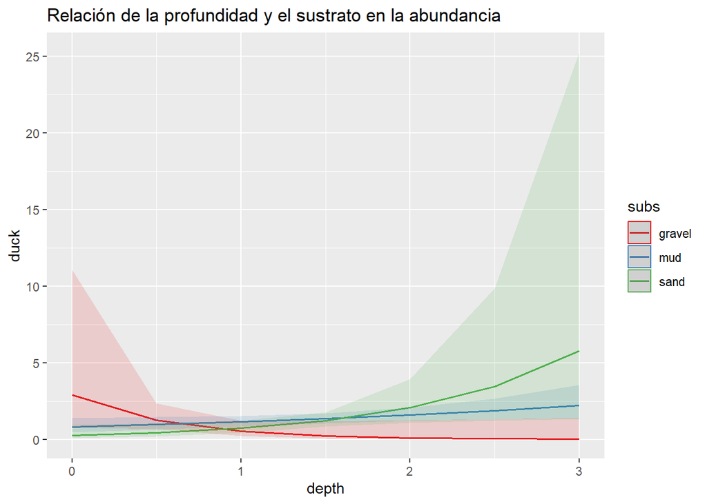

```r
sjPlot::plot_model(Modelos_duck$int_pro_sus, type = "int",
                   terms = "subs*depth") +
  labs(title = "Relación de la profundidad y el sustrato en la abundancia")
```

```r
ggsave("resultados/duck_int_pro_sus.png", plot = last_plot(),
       units = "cm", width = 15, height = 9, dpi = 350)
```

### 7.2 Modelo2 = profundidad

```r
plot_profundidad = ggpredict(Modelos_duck$profundidad, terms = "depth[n = 100]")
```

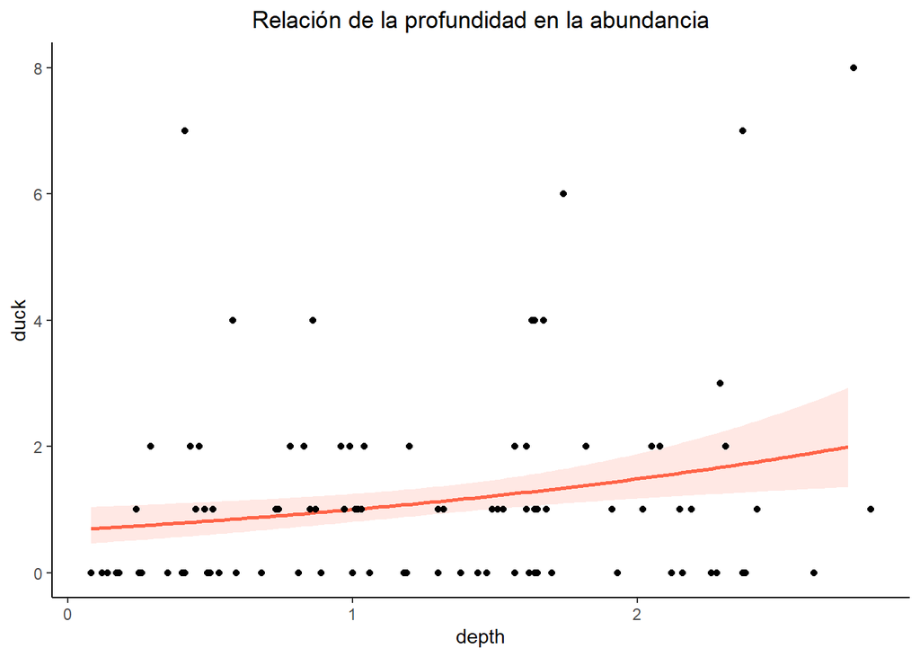

```r
plot(plot_profundidad, colors = "tomato", line = 1) +
  geom_point(data = mejillones, aes(x = depth, y = duck)) +
  labs(title = "Relación de la profundidad en la abundancia") +
  theme_classic() +
  theme(plot.title = element_text(hjust = 0.5, face = 1))
```

```r
ggsave("resultados/duck_profundidad.png", plot = last_plot(),
       units = "cm", width = 15, height = 9, dpi = 350)
```